# Taller Uno Minería Datos

Programa Ingeniería de Sistemas

Ing. Julian Andrés Quimbayo

2021-02-28

## Matrices en R

Con el ánimo de generar una práctica de los conceptos adquiridos hasta el momento se presenta el siguiente desafío para todos. Se va a utilizar un dataset denominado **post-operative.data**, los cuales son datos de pacientes que estan por salir de post operatorio. Para conocer el dataset de manera mas profunda visitar: https://archive.ics.uci.edu/ml/datasets/Post-Operative+Patient

Nota: *El dataset se encuentra en la plataforma Moodle*

### Paso 1: Importación del dataset, nombre de la matriz

Nota: *nombre de la matriz est_pacientes*

```
## # A tibble: 90 x 9
##    X1    X2    X3        X4    X5       X6       X7         X8    X9
##    <chr> <chr> <chr>     <chr> <chr>    <chr>    <chr>      <chr> <chr>
##  1 mid   low   excellent mid   stable   stable   stable     15    A
##  2 mid   high  excellent high  stable   stable   stable     10    S
##  3 high  low   excellent high  stable   stable   mod-stable 10    A
##  4 mid   low   good      high  stable   unstable mod-stable 15    A
##  5 mid   mid   excellent high  stable   stable   stable     10    A
##  6 high  low   good      mid   stable   stable   unstable   15    S
##  7 mid   low   excellent high  stable   stable   mod-stable 05    S
##  8 high  mid   excellent mid   unstable unstable stable     10    S
##  9 mid   high  good      mid   stable   stable   stable     10    S
## 10 mid   low   excellent mid   unstable stable   mod-stable 10    S
## # ... with 80 more rows
```

### Paso 2: Conversión a Matriz

Nota: *nombre de la matriz final pac*

```
##      X1     X2     X3          X4     X5       X6         X7           X8   X9
## [1,] "mid"  "low"  "excellent" "mid"  "stable" "stable"   "stable"     "15" "A"
## [2,] "mid"  "high" "excellent" "high" "stable" "stable"   "stable"     "10" "S"
## [3,] "high" "low"  "excellent" "high" "stable" "stable"   "mod-stable" "10" "A"
## [4,] "mid"  "low"  "good"      "high" "stable" "unstable" "mod-stable" "15" "A"
## [5,] "mid"  "mid"  "excellent" "high" "stable" "stable"   "stable"     "10" "A"
## [6,] "high" "low"  "good"      "mid"  "stable" "stable"   "unstable"   "15" "S"
```

### Paso 3: Revisar la estructura de la Matriz

```
##  chr [1:90, 1:9] "mid" "mid" "high" "mid" "mid" "high" "mid" "high" "mid" ...
##  - attr(*, "dimnames")=List of 2
##   ..$ : NULL
##   ..$ : chr [1:9] "X1" "X2" "X3" "X4" ...
```

### Paso 4: Pasar los datos a Español

Nota: *nombre de la matriz final pac*

```
##      X1      X2      X3          X4      X5        X6          X7
## [1,] "Medio" "Bajo"  "Excelente" "Media" "Estable" "Estable"   "Estable"
## [2,] "Medio" "Alto"  "Excelente" "Alta"  "Estable" "Estable"   "Estable"
## [3,] "Alto"  "Bajo"  "Excelente" "Alta"  "Estable" "Estable"   "Medio Estable"
## [4,] "Medio" "Bajo"  "Bueno"     "Alta"  "Estable" "Inestable" "Medio Estable"
## [5,] "Medio" "Medio" "Excelente" "Alta"  "Estable" "Estable"   "Estable"
## [6,] "Alto"  "Bajo"  "Bueno"     "Media" "Estable" "Estable"   "Inestable"
##      X8   X9
## [1,] "15" "A"
## [2,] "10" "S"
## [3,] "10" "A"
## [4,] "15" "A"
## [5,] "10" "A"
## [6,] "15" "S"
```

### Paso 5: Cambiar el tipo de dato char a numerico en la columna 8

Nota: *Extraer solo esa columna y tratarla(Reemplazar datos de tipo NA por la media)*

```
## [1] "character"
```

```
##  [1] "15" "10" "10" "15" "10" "15" "05" "10" "10" "10" "15" "10" "15" "10" "15"
## [16] "10" "15" "10" "15" "10" "15" "10" "15" "10" "10" "10" "10" "10" "15" "10"
## [31] "10" "10" "10" "10" "10" "10" "10" "10" "07" "10" "10" "15" "15" "10" "10"
## [46] "10" "?"  "10" "?"  "10" "10" "10" "10" "10" "10" "15" "15" "10" "10" "10"
## [61] "10" "10" "10" "10" "10" "10" "10" "10" "10" "10" "?"  "10" "10" "10" "10"
## [76] "10" "10" "10" "10" "10" "15" "10" "10" "05" "10" "10" "15" "15" "10" "15"
```

```
##  [1] 15 10 10 15 10 15  5 10 10 10 15 10 15 10 15 10 15 10 15 10 15 10 15 10 10
## [26] 10 10 10 15 10 10 10 10 10 10 10 10 10  7 10 10 15 15 10 10 10 NA 10 NA 10
## [51] 10 10 10 10 10 15 15 10 10 10 10 10 10 10 10 10 10 10 10 10 NA 10 10 10 10
## [76] 10 10 10 10 10 15 10 10  5 10 10 15 15 10 15
```

### Paso 6: Uso de Summary y limpieza de datos NA por la media.

Nota: *Extraer solo esa columna y tratarla(Reemplazar datos de tipo NA por la media)*

```
##    Min. 1st Qu.  Median    Mean 3rd Qu.    Max.    NA's
##    5.00   10.00   10.00   10.94   10.00   15.00       3
```

```
## [1] 10.94253
```

```
## [1] 10.9
```

```
##  [1] 15.0 10.0 10.0 15.0 10.0 15.0  5.0 10.0 10.0 10.0 15.0 10.0 15.0 10.0 15.0
## [16] 10.0 15.0 10.0 15.0 10.0 15.0 10.0 15.0 10.0 10.0 10.0 10.0 10.0 15.0 10.0
## [31] 10.0 10.0 10.0 10.0 10.0 10.0 10.0 10.0  7.0 10.0 10.0 15.0 15.0 10.0 10.0
## [46] 10.0 10.9 10.0 10.9 10.0 10.0 10.0 10.0 10.0 10.0 15.0 15.0 10.0 10.0 10.0
## [61] 10.0 10.0 10.0 10.0 10.0 10.0 10.0 10.0 10.0 10.0 10.9 10.0 10.0 10.0 10.0
## [76] 10.0 10.0 10.0 10.0 10.0 15.0 10.0 10.0  5.0 10.0 10.0 15.0 15.0 10.0 15.0
```

### Paso 7: Eliminar columna 8 de la matriz original y colocarla al final con los datos ya limpios de NA

```
##       X1      X2      X3          X4      X5          X6
##  [1,] "Medio" "Bajo"  "Excelente" "Media" "Estable"   "Estable"
##  [2,] "Medio" "Alto"  "Excelente" "Alta"  "Estable"   "Estable"
##  [3,] "Alto"  "Bajo"  "Excelente" "Alta"  "Estable"   "Estable"
##  [4,] "Medio" "Bajo"  "Bueno"     "Alta"  "Estable"   "Inestable"
##  [5,] "Medio" "Medio" "Excelente" "Alta"  "Estable"   "Estable"
##  [6,] "Alto"  "Bajo"  "Bueno"     "Media" "Estable"   "Estable"
##  [7,] "Medio" "Bajo"  "Excelente" "Alta"  "Estable"   "Estable"
##  [8,] "Alto"  "Medio" "Excelente" "Media" "Inestable" "Inestable"
##  [9,] "Medio" "Alto"  "Bueno"     "Media" "Estable"   "Estable"
## [10,] "Medio" "Bajo"  "Excelente" "Media" "Inestable" "Estable"
## [11,] "Medio" "Medio" "Bueno"     "Media" "Estable"   "Estable"
## [12,] "Medio" "Bajo"  "Bueno"     "Alta"  "Estable"   "Estable"
## [13,] "Alto"  "Alto"  "Excelente" "Alta"  "Inestable" "Estable"
## [14,] "Medio" "Alto"  "Bueno"     "Media" "Inestable" "Estable"
```

[output cut: 167 more lines]

```
##       X1      X2      X3          X4      X5          X6
##  [1,] "Medio" "Bajo"  "Excelente" "Media" "Estable"   "Estable"
##  [2,] "Medio" "Alto"  "Excelente" "Alta"  "Estable"   "Estable"
##  [3,] "Alto"  "Bajo"  "Excelente" "Alta"  "Estable"   "Estable"
##  [4,] "Medio" "Bajo"  "Bueno"     "Alta"  "Estable"   "Inestable"
##  [5,] "Medio" "Medio" "Excelente" "Alta"  "Estable"   "Estable"
##  [6,] "Alto"  "Bajo"  "Bueno"     "Media" "Estable"   "Estable"
##  [7,] "Medio" "Bajo"  "Excelente" "Alta"  "Estable"   "Estable"
##  [8,] "Alto"  "Medio" "Excelente" "Media" "Inestable" "Inestable"
##  [9,] "Medio" "Alto"  "Bueno"     "Media" "Estable"   "Estable"
## [10,] "Medio" "Bajo"  "Excelente" "Media" "Inestable" "Estable"
## [11,] "Medio" "Medio" "Bueno"     "Media" "Estable"   "Estable"
## [12,] "Medio" "Bajo"  "Bueno"     "Alta"  "Estable"   "Estable"
## [13,] "Alto"  "Alto"  "Excelente" "Alta"  "Inestable" "Estable"
## [14,] "Medio" "Alto"  "Bueno"     "Media" "Inestable" "Estable"
```

[output cut: 167 more lines]

### Paso 8: Convertir la matriz a dataframes se usa *as.data.frame*, revisar igualmente la estructura con str.

```
##      X1    X2        X3    X4      X5        X6            X7 X9 datosnume
## 1 Medio  Bajo Excelente Media Estable   Estable       Estable  A        15
## 2 Medio  Alto Excelente  Alta Estable   Estable       Estable  S        10
## 3  Alto  Bajo Excelente  Alta Estable   Estable Medio Estable  A        10
## 4 Medio  Bajo     Bueno  Alta Estable Inestable Medio Estable  A        15
## 5 Medio Medio Excelente  Alta Estable   Estable       Estable  A        10
## 6  Alto  Bajo     Bueno Media Estable   Estable     Inestable  S        15
```

```
## 'data.frame':    90 obs. of  9 variables:
##  $ X1       : Factor w/ 3 levels "Alto","Bajo",..: 3 3 1 3 3 1 3 1 3 3 ...
##  $ X2       : Factor w/ 3 levels "Alto","Bajo",..: 2 1 2 2 3 2 2 3 1 2 ...
##  $ X3       : Factor w/ 2 levels "Bueno","Excelente": 2 2 2 1 2 1 2 2 1 2 ...
##  $ X4       : Factor w/ 3 levels "Alta","Baja",..: 3 1 1 1 1 3 1 3 3 3 ...
##  $ X5       : Factor w/ 2 levels "Estable","Inestable": 1 1 1 1 1 1 1 2 1 2 ...
##  $ X6       : Factor w/ 3 levels "Estable","Inestable",..: 1 1 1 2 1 1 1 2 1 1 ...
##  $ X7       : Factor w/ 3 levels "Estable","Inestable",..: 1 1 3 3 1 2 3 1 1 3 ...
##  $ X9       : Factor w/ 3 levels "A","I","S": 1 3 1 1 1 3 3 3 3 3 ...
##  $ datosnume: Factor w/ 5 levels "10","10.9","15",..: 3 1 1 3 1 3 4 1 1 1 ...
```

### Paso 9: Convertir la ultima columna a dato numérico ya que es un factor.

```
##      X1    X2        X3    X4      X5        X6            X7 X9 datosnume
## 1 Medio  Bajo Excelente Media Estable   Estable       Estable  A        15
## 2 Medio  Alto Excelente  Alta Estable   Estable       Estable  S        10
## 3  Alto  Bajo Excelente  Alta Estable   Estable Medio Estable  A        10
## 4 Medio  Bajo     Bueno  Alta Estable Inestable Medio Estable  A        15
## 5 Medio Medio Excelente  Alta Estable   Estable       Estable  A        10
## 6  Alto  Bajo     Bueno Media Estable   Estable     Inestable  S        15
```

```
##      X1    X2        X3    X4      X5        X6            X7 X9 datosnume
## 1 Medio  Bajo Excelente Media Estable   Estable       Estable  A        15
## 2 Medio  Alto Excelente  Alta Estable   Estable       Estable  S        10
## 3  Alto  Bajo Excelente  Alta Estable   Estable Medio Estable  A        10
## 4 Medio  Bajo     Bueno  Alta Estable Inestable Medio Estable  A        15
## 5 Medio Medio Excelente  Alta Estable   Estable       Estable  A        10
## 6  Alto  Bajo     Bueno Media Estable   Estable     Inestable  S        15
```

```
## 'data.frame':    90 obs. of  9 variables:
##  $ X1       : Factor w/ 3 levels "Alto","Bajo",..: 3 3 1 3 3 1 3 1 3 3 ...
##  $ X2       : Factor w/ 3 levels "Alto","Bajo",..: 2 1 2 2 3 2 2 3 1 2 ...
##  $ X3       : Factor w/ 2 levels "Bueno","Excelente": 2 2 2 1 2 1 2 2 1 2 ...
##  $ X4       : Factor w/ 3 levels "Alta","Baja",..: 3 1 1 1 1 3 1 3 3 3 ...
##  $ X5       : Factor w/ 2 levels "Estable","Inestable": 1 1 1 1 1 1 1 2 1 2 ...
##  $ X6       : Factor w/ 3 levels "Estable","Inestable",..: 1 1 1 2 1 1 1 2 1 1 ...
##  $ X7       : Factor w/ 3 levels "Estable","Inestable",..: 1 1 3 3 1 2 3 1 1 3 ...
##  $ X9       : Factor w/ 3 levels "A","I","S": 1 3 1 1 1 3 3 3 3 3 ...
##  $ datosnume: num  15 10 10 15 10 15 5 10 10 10 ...
```

### Paso 10: Colocarle nombres de columnas y filas al dataframe.

```
##             L-CORE L-SURF      L-O2  L-BP SURF-STBL     CORE-STBL       BP-STBL
## Paciente 1   Medio   Bajo Excelente Media   Estable       Estable       Estable
## Paciente 2   Medio   Alto Excelente  Alta   Estable       Estable       Estable
## Paciente 3    Alto   Bajo Excelente  Alta   Estable       Estable Medio Estable
## Paciente 4   Medio   Bajo     Bueno  Alta   Estable     Inestable Medio Estable
## Paciente 5   Medio  Medio Excelente  Alta   Estable       Estable       Estable
## Paciente 6    Alto   Bajo     Bueno Media   Estable       Estable     Inestable
## Paciente 7   Medio   Bajo Excelente  Alta   Estable       Estable Medio Estable
## Paciente 8    Alto  Medio Excelente Media Inestable     Inestable       Estable
## Paciente 9   Medio   Alto     Bueno Media   Estable       Estable       Estable
## Paciente 10  Medio   Bajo Excelente Media Inestable       Estable Medio Estable
## Paciente 11  Medio  Medio     Bueno Media   Estable       Estable       Estable
## Paciente 12  Medio   Bajo     Bueno  Alta   Estable       Estable Medio Estable
## Paciente 13   Alto   Alto Excelente  Alta Inestable       Estable     Inestable
## Paciente 14  Medio   Alto     Bueno Media Inestable       Estable Medio Estable
## Paciente 15  Medio   Bajo     Bueno  Alta Inestable     Inestable       Estable
## Paciente 16   Alto   Alto Excelente  Alta Inestable       Estable     Inestable
## Paciente 17   Bajo   Alto     Bueno  Alta Inestable       Estable Medio Estable
## Paciente 18  Medio   Bajo     Bueno  Alta Inestable       Estable       Estable
## Paciente 19  Medio   Alto     Bueno Media Inestable       Estable     Inestable
## Paciente 20  Medio  Medio     Bueno Media   Estable       Estable       Estable
## Paciente 21   Bajo   Alto     Bueno Media Inestable       Estable       Estable
## Paciente 22   Bajo  Medio Excelente  Alta Inestable       Estable     Inestable
## Paciente 23  Medio  Medio     Bueno Media Inestable       Estable     Inestable
## Paciente 24  Medio  Medio     Bueno Media Inestable       Estable       Estable
## Paciente 25   Alto   Alto     Bueno Media   Estable       Estable Medio Estable
## Paciente 26   Bajo  Medio     Bueno Media Inestable       Estable       Estable
## Paciente 27   Alto  Medio     Bueno  Baja   Estable       Estable Medio Estable
## Paciente 28   Bajo  Medio Excelente  Alta   Estable       Estable Medio Estable
## Paciente 29  Medio  Medio Excelente Media   Estable       Estable     Inestable
## Paciente 30  Medio  Medio     Bueno Media Inestable       Estable     Inestable
## Paciente 31  Medio  Medio     Bueno  Alta Inestable       Estable       Estable
## Paciente 32   Bajo   Bajo     Bueno Media Inestable       Estable     Inestable
## Paciente 33  Medio  Medio Excelente  Alta Inestable       Estable Medio Estable
## Paciente 34  Medio   Bajo     Bueno Media   Estable       Estable       Estable
## Paciente 35   Bajo  Medio Excelente  Alta   Estable       Estable Medio Estable
## Paciente 36  Medio  Medio     Bueno Media   Estable       Estable       Estable
## Paciente 37   Bajo  Medio Excelente Media   Estable       Estable       Estable
## Paciente 38   Bajo   Bajo     Bueno Media Inestable       Estable     Inestable
## Paciente 39   Bajo   Bajo     Bueno Media   Estable       Estable       Estable
```

[output cut: 127 more lines]

```
## Paciente 76        A    10.0
## Paciente 77        A    10.0
## Paciente 78        A    10.0
## Paciente 79        S    10.0
## Paciente 80        A    10.0
## Paciente 81        A    15.0
## Paciente 82        S    10.0
## Paciente 83        I    10.0
## Paciente 84        A     5.0
## Paciente 85        A    10.0
## Paciente 86        A    10.0
## Paciente 87        S    15.0
## Paciente 88        A    15.0
## Paciente 89        A    10.0
## Paciente 90        S    15.0
```

### Paso 11: Algunas gráficas de interés.

Gráfica uno: *Pacientes con niveles de Oxigeno* Gráfica dos: *Pacientes con Estado de Salida* Nota: *Se usa la librería ggplot2*

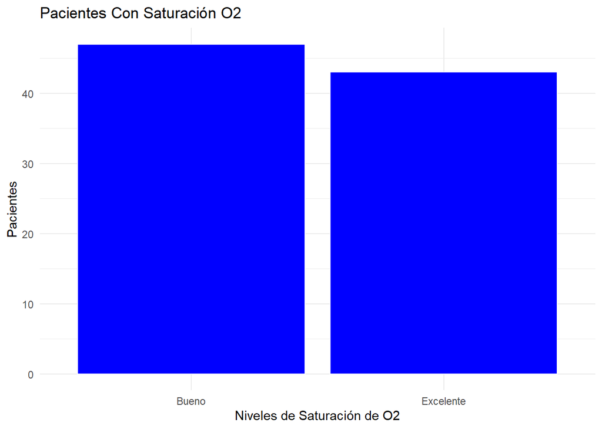

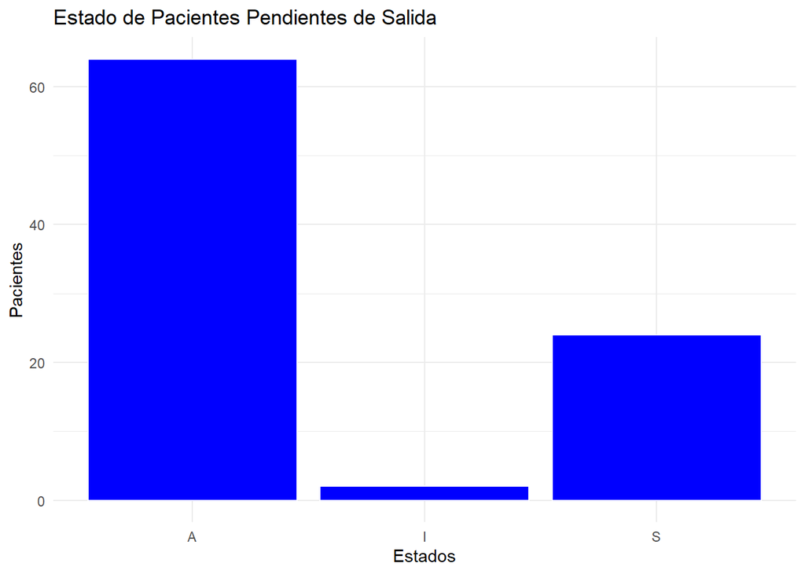

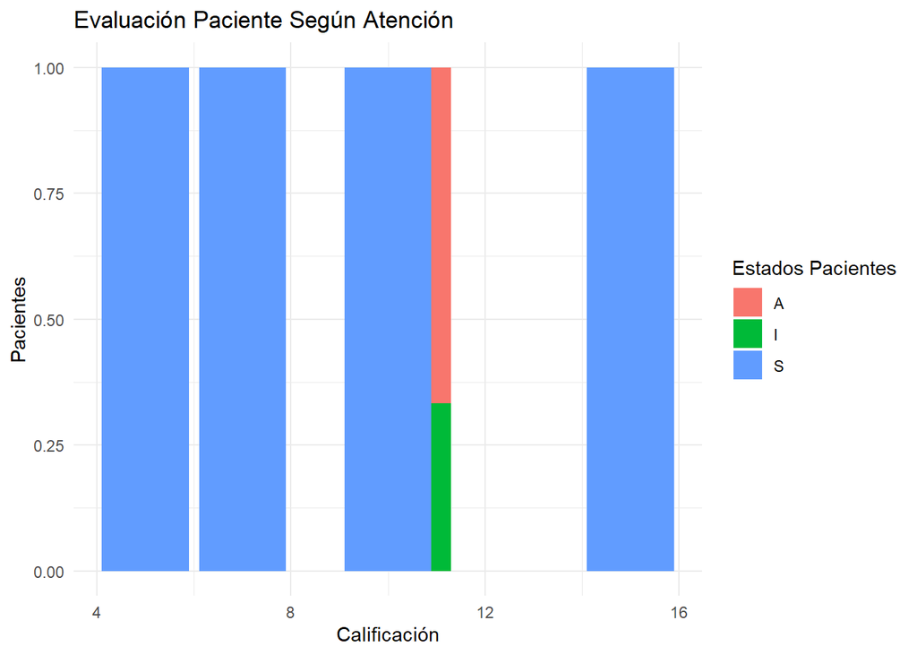